### **Разведывательный анализ данных платформы Kickstarter с целью определить, какой проект с наибольшей вероятностью сможет стать успешным.**

С помощью статистического теста Хи квадрат определим, от каких переменных исходного датасета  
зависит успех проекта - state (т.е. для каких переменных P-value < 0.05)

| p.values | characteristics |
| --- | --- |
| 0.5008931 | launched |
| 0.4854247 | name |
| 0.0000000 | deadline |
| 0.0000000 | goal |
| 0.0000000 | currency |
| 0.0000000 | country |
| 0.0000000 | category |
| 0.0000000 | main_category |
| 0.0000000 | backers |

*Как мы видим, статус проекта зависит от всех переменных, кроме “launched” и “name”.*

Однако проводить анализ такого количества характеристик затруднительно.  
Поэтому, чтобы выделить наиболее важные из них, мы:  
1. Разделим выборку на обучающую и тестовую (чтобы в будущем убедиться в том, что модель работает не только на исходных данных).  
2. Построим дерево, зависящее сразу от всех переменных датасета  
3. “Обрежем” дерево так, чтобы по нему было удобно производить анализ.

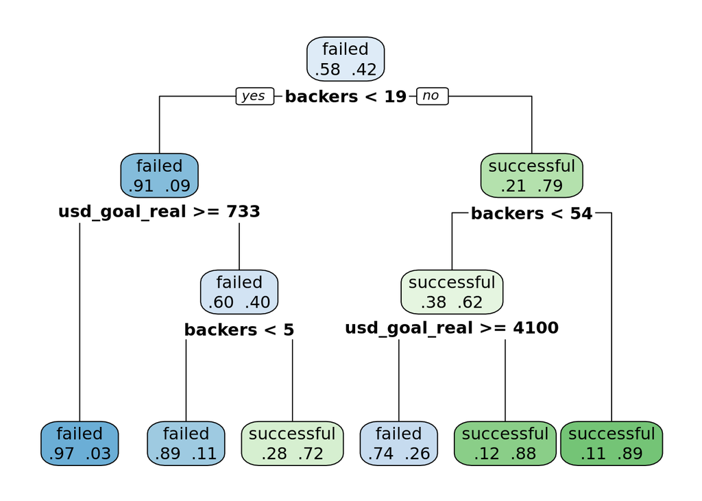

*Из полученного дерева мы видим, что наиболее значительную роль в определении успеха играют*  
*такие факторы, как: “backers” и “usd_goal_real”.*

Проверим точность полученной модели.

|  | failed | successful |
| --- | --- | --- |
| failed | 17931 | 2011 |
| successful | 1279 | 13447 |

#### **точность обучающей модели = 0.9050998**

|  | failed | successful |
| --- | --- | --- |
| failed | 4453 | 511 |
| successful | 333 | 3370 |

#### **точность тестовой модели = 0.9026191**

Получается, статус проекта в основном зависит от таких переменных, как “Goal” и “Backers”.  
При этом, вероятность ошибиться, предсказывая по этим двум категориям успех, менее 10% (точность модели > 90%).

### *Рассмотрим подробнее характеристику “usd_goal_real”*

Насколько сильна взаимосвязь между стоимостью (usd_goal_real) и успешностью (state) проекта?

|  | failed | successful |
| --- | --- | --- |
| failed | 17730 | 11447 |
| successful | 2212 | 3279 |

#### **точность обучающей модели = 0.6060055**

|  | failed | successful |
| --- | --- | --- |
| failed | 4425 | 2886 |
| successful | 539 | 817 |

#### **точность тестовой модели = 0.6048229**

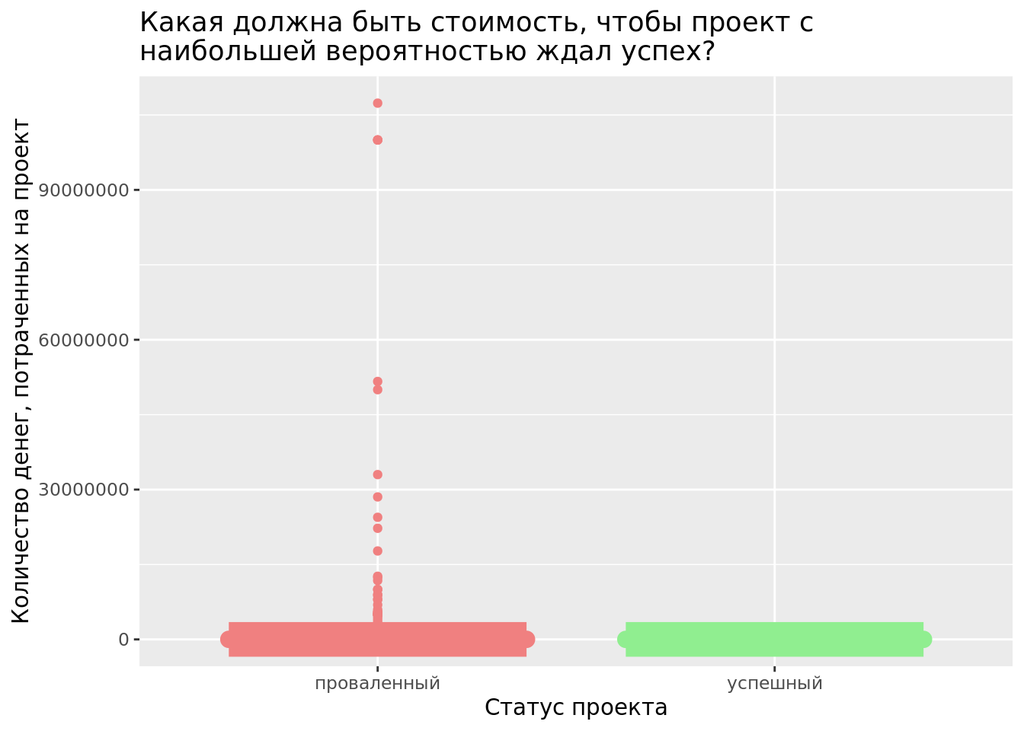

### *Рассмотрим подробнее характеристику “backers”*

Насколько сильна взаимосвязь между количеством инвесторов (backers) и успешностью проекта (state)?

|  | failed | successful |
| --- | --- | --- |
| failed | 16517 | 1657 |
| successful | 3425 | 13069 |

#### **точность обучающей модели = 0.8534095**

|  | failed | successful |
| --- | --- | --- |
| failed | 4139 | 447 |
| successful | 825 | 3256 |

#### **точность тестовой модели = 0.8532364**

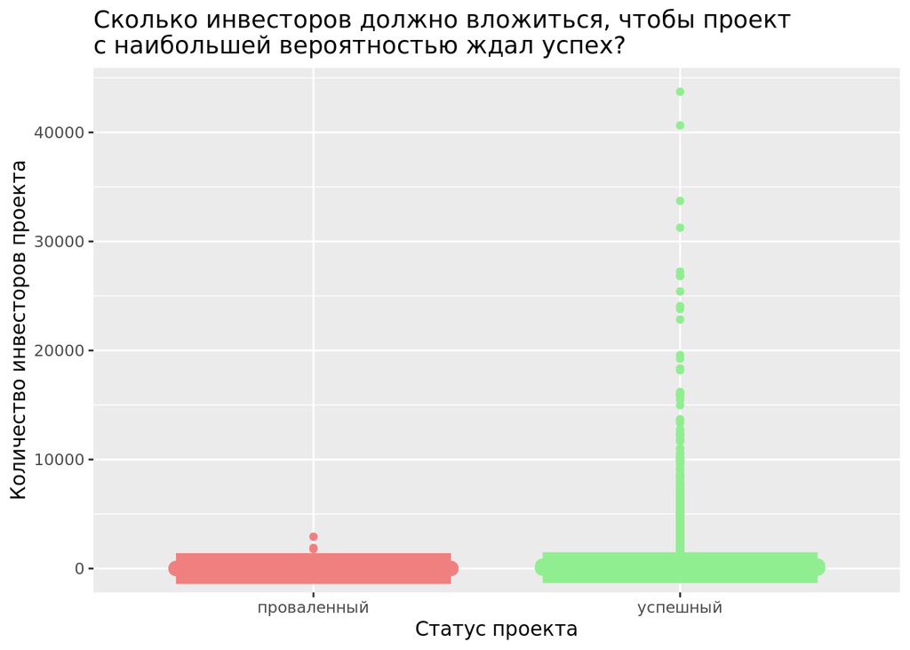

#### Какой вывод можно сделать из полученных данных?

#### Как мы можем оптимизировать выбор, планируя проект?

**1. Свести к минимуму затраты на проект (однако лишь эта мера даст нам желаемый результат с точностью только 60%).**  
**2. Привлечь к проекту максимальное количество инвесторов.**  
Очевидно, что первый фактор мы можем контролировать. Но возможно ли повлиять на второй?

#### От чего зависит выбор инвесторов?

#### Сможем ли мы оказать влияние на их решение?

C помощью теста Хи квадрат попробуем узнать, от каких переменных датасета зависят  
решения инвесторов (то есть для каких переменных значение P-value < 0.05)

| p.values | categories |
| --- | --- |
| 1.0000000 | category |
| 1.0000000 | main_category |
| 1.0000000 | currency |
| 1.0000000 | deadline |
| 1.0000000 | country |
| 1.0000000 | goal |
| 1.0000000 | launched |
| 0.0000179 | name |
| 0.0000000 | state |

Как видим, статус зависит от переменных **name** и **state**.  
Зависимость backers от state, была получена ранее, поэтому обратим внимание именно на **name**.  
Попробуем выяснить, каким образом эта переменная влияет на количество инвесторов.  
Узнаем, зависит ли количество инвесторов проекта от длины его названия, построив график на данных исходного датасета.

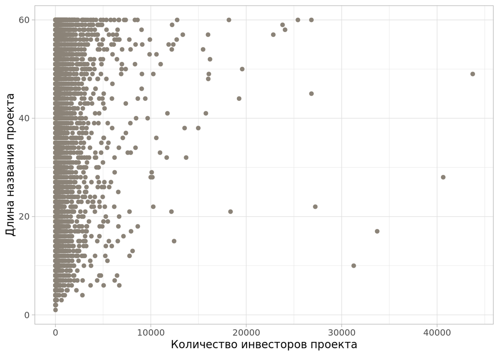

На графике невозможно заметить четкую взаимосвязь переменных.  
Но, может, мы просто не видим ее?  
*Проверим корреляцию с помощью теста Хи-квадрат.*

```
## [1] "P-value = 1"
```

Выходит, количество инвесторов зависит от названия проекта, однако не от его длины.  
Если мы будем строить слишком подробную модель на основе названия (не его длины, а других характеристик),  
она, скорее всего, не будет работать на тестовой выборке.  
Получается, что, исходя из представленных данных, **мы не можем доподлинно предсказать выбор инвесторов**.

#### **Сможем ли мы принять точно верное решение, создавая проект, основываясь лишь на его стоимости, учитывая, что точность такого решения лишь 60%?**

#### **Скорее всего, нет.**

Тогда вспомним, что в самом начале анализа мы отбросили несколько значимых переменных - category, main_category, country, currency, deadline.

Исключив их, мы получили данные, учитывающие возможность ошибок в исходной выборке. Однако, поскольку анализ без этих переменных не привел к значимым результатам, рассмотрим их, пожертвовав при этом универсальностью модели. Найдем характеристики, которые предсказывают модель с максимальной точностью (accuracy).

| characteristics | train_accuracy | test_accuracy |
| --- | --- | --- |
| category | 0.6415112 | 0.6129032 |
| main_category | 0.5989285 | 0.6774194 |
| country | 0.5747737 | 0.5161290 |
| currency | 0.5747737 | 0.5161290 |
| deadline | 0.5747737 | 0.5161290 |

Мы получили, что больше всего из упущенных нами сперва характеристик со статусом проекта коррелирует “category”.

### *Рассмотрим подробнее характеристику “category”*

В какую категорию с наибольшей вероятностью вложится максимальное число инвесторов?  
(т.е. где “success_frequency” максимально?)

|  | category | total_num | num_success | success_frequency |
| --- | --- | --- | --- | --- |
| 1 | Tabletop Games | 2661 | 1972 | 0.741074783915821 |
| 2 | Performances | 167 | 123 | 0.736526946107784 |
| 3 | Anthologies | 205 | 149 | 0.726829268292683 |
| 4 | Country &amp; Folk | 350 | 254 | 0.725714285714286 |
| 5 | Comic Books | 771 | 550 | 0.713359273670558 |
| 6 | Comics | 306 | 217 | 0.709150326797386 |
| 7 | Graphic Novels | 423 | 280 | 0.66193853427896 |
| 8 | Illustration | 725 | 478 | 0.659310344827586 |
| 9 | Zines | 83 | 54 | 0.650602409638554 |
| 10 | Jazz | 151 | 98 | 0.649006622516556 |

[output cut: 110 more lines]

Отфильтровав датасет так, чтобы в него попали лишь категории, встретившиеся более 50ти раз (чтобы исключить возможность сделать случайный выбор), получим список категорий, которые (с точностью примерно 61-64%) ждет успех:  
Tabletop Games, Performances, Anthologies, Country & Folk, Comic Books

#### **Какие выводы можно сделать теперь из нашего анализа?**

#### **Как можно максимизировать вероятность успеха, принимая решение о судьбе проекта?**

#### **1. Goal_real.** Необходимо определить минимальный размер необходимых для осуществления проекта средств.

#### **2. Backers.** Нужно привлечь в проект наибольшее число инвесторов. Анализ не показал существенной взаимосвязи решений инвесторов с имеющимися у нас данными. Исходя из здравого смысла, предположим, что, чтобы максимизировать число инвесторов, необходимо воспользоваться маркетинговыми услугами.

#### **3. Categories.** Наиболее “выигрышными” категориями с точки зрения успешности являются: Tabletop Games, Performances, Anthologies, Country & Folk, Comic Books. Следовательно, нужно ориентироваться на них, выбирая категорию проекта.